# knn

Dr. Naveen Kumar

2024-03-05

# Understanding the Concept of KNN Algorithm Using R

`Machine learning` is a subset of `Artificial Intelligence` that provides machines the power to find out automatically and improve from their gained experience without being explicitly programmed.

Three types of Machine Learning:

## 1. Supervised Learning:

Machine Learning in which the data provided for teaching or training the machine is well `labeled` and so it becomes easy to work with it.

## 2. Unsupervised Learning:

Training of information using a machine that is `unlabelled` and allowing the algorithm to act on that information without guidance.

## 3. Reinforcement Learning:

It is that part of Machine Learning where an `agent` is put in an environment and he learns to behave by performing certain actions and observing the various possible outcomes which it gets from those actions.

# K Nearest Neighbor Algorithm?

- `KNN` stands for `K Nearest Neighbor` is a `Supervised Machine Learning` algorithm that `classifies` a new data point into the target class, counting on the features of its neighboring data points.
- popular machine learning technique used for classification and regression tasks.
- It relies on the idea that similar data points tend to have similar labels or values.
- During the training phase, the KNN algorithm stores the entire training dataset as a reference.
- When making predictions, it calculates the `distance` between the input data point and all the training examples, using a chosen distance metric such as `Euclidean` distance.
- Next, the algorithm identifies the `K nearest neighbors` to the input data point based on their distances.
- In the case of classification, the algorithm assigns the most common class label among the K neighbors as the predicted label for the input data point.

For regression, it calculates the average or weighted average of the target values of the K neighbors to predict the value for the input data point.

we want a machine to distinguish between the sentiment of tweets posted by various users. To do this we must input a dataset of users’ sentiment(comments).  
And now, we have to train our model to detect the sentiments based on certain features such as labeled tweet sentiment i.e., as `positive` or `negative` tweets accordingly. If a tweet is `positive`, it is labeled as `1`and if `negative`, then labeled as `0`.

- The KNN algorithm is `straightforward and easy to understand`, making it a popular choice in various domains. - However, its performance can be affected by the `choice of K` and the `distance metric`, so careful parameter tuning is necessary for optimal results.

## When to use KNN

- KNN Algorithm can be used for both classification and regression predictive problems.
- However, it is more widely used in classification problems in the industry.
- To evaluate any technique, we generally look at 3 important aspects:
1. Ease of interpreting output
2. Calculation time
3. Predictive Power

## Features of KNN algorithm:

KNN is a `supervised learning algorithm`, based on `feature similarity`.

Unlike most algorithms, KNN is a non-parametric model which means it does not make any assumptions about the data set. This makes the algorithm simpler and effective since it can handle realistic data.

KNN is considered to be a `lazy algorithm`, i.e., it suggests that it memorizes the training data set rather than learning a discriminative function from the training data.

KNN is often used for solving both `classification` and `regression` problems.

Step 2: Data Cleaning

Step 3: Data Normalization

Step 4: Data Splicing

Step 5: Building a Machine Learning model

Step 6: Model Evaluation

# Introduction to K Nearest Neighbor

widely used machine learning classification technique called the k-nearest neighbors (KNN) algorithm. How the algorithm works on new data and how the input parameter affects the output/prediction.

## Learning Objectives

- Understand the working of KNN and how it operates in R.
- Get to know how to choose the right value of k for KNN
- Understand the difference between training error rate and validation error rate.

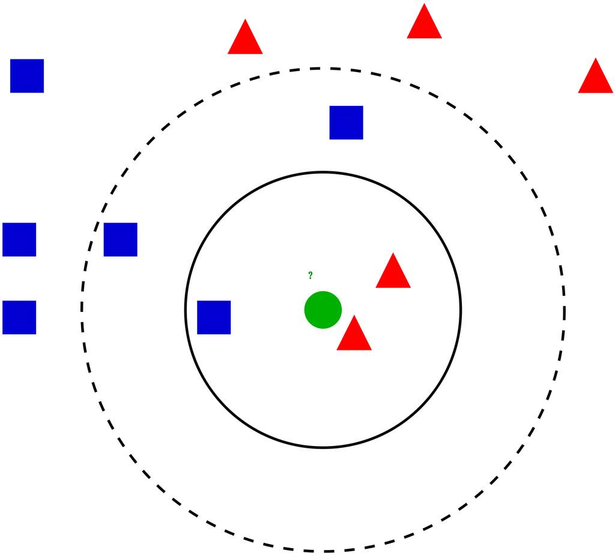

KNN Visually

## Pseudo Code of KNN

We can implement a KNN model by following the below steps:

1. Load the data
2. Initialise the value of k
3. For getting the predicted class, iterate from 1 to total number of training data points
- Calculate the distance between test data and each row of training dataset. Here we will use `Euclidean distance` as distance metric since it’s the most popular method. The other distance function or metrics that can be used are `Manhattan distance`, `Minkowski distance`, `Chebyshev`, `cosine`, etc. If there are categorical variables, `hamming distance` can be used.
- Sort the calculated distances in ascending order based on distance values
- Get top k rows from the sorted array
- Get the most frequent class of these rows
- Return the predicted class